# Train Route Analysis and Journey Time Prediction

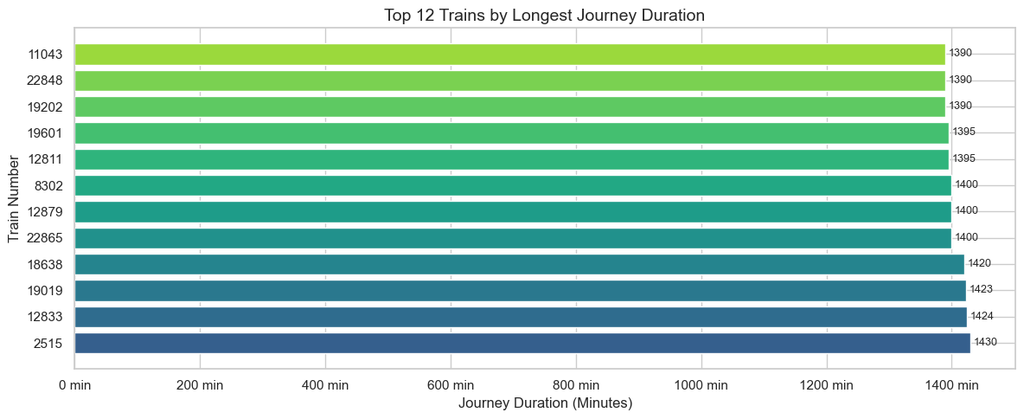

```python
# ── CELL 7 ── Task 3.1 & 4.1: Journey Duration by Route ─────
route_duration = (
    rail_data.groupby('Train_No')['Elapsed_Minutes']
    .max()
    .sort_values(ascending=False)
    .head(12)
    .reset_index()
)
route_duration.columns = ['Train_No', 'Max_Duration_Min']

fig, ax = plt.subplots(figsize=(12, 5))
bars = ax.barh(
    route_duration['Train_No'].astype(str),
    route_duration['Max_Duration_Min'],
    color=plt.cm.viridis(np.linspace(0.3, 0.85, len(route_duration)))
)
ax.set_xlabel('Journey Duration (Minutes)')
ax.set_ylabel('Train Number')
ax.set_title('Top 12 Trains by Longest Journey Duration')
ax.xaxis.set_major_formatter(mticker.FuncFormatter(lambda x, _: f'{int(x)} min'))
for bar, val in zip(bars, route_duration['Max_Duration_Min']):
    ax.text(bar.get_width() + 5, bar.get_y() + bar.get_height()/2,
            f'{val:.0f}', va='center', fontsize=9)
plt.tight_layout()
plt.savefig('chart_journey_duration.png', bbox_inches='tight')
plt.show()
```

```python
# ── CELL 8 ── Task 3.2 & 4.2: Station-wise Train Traffic ────
traffic_by_station = (
    rail_data.groupby('Station_Name')['Train_No']
    .nunique()
    .sort_values(ascending=False)
)

print("── TOP 10 BUSIEST STATIONS ──")
print(traffic_by_station.head(10).to_string())
print("\n── 10 LEAST BUSY STATIONS ──")
print(traffic_by_station.tail(10).to_string())

# Chart: top 15 stations
top_stations = traffic_by_station.head(15)
fig, ax = plt.subplots(figsize=(13, 5))
colors = sns.color_palette("rocket", len(top_stations))
ax.bar(top_stations.index, top_stations.values, color=colors, edgecolor='white', linewidth=0.6)
ax.set_title('Top 15 Stations by Train Traffic Volume')
ax.set_xlabel('Station Name')
ax.set_ylabel('Number of Trains Passing')
plt.xticks(rotation=50, ha='right', fontsize=9)
plt.tight_layout()
plt.savefig('chart_station_traffic.png', bbox_inches='tight')
plt.show()
```

[output not shown]

```
── TOP 10 BUSIEST STATIONS ──
Station_Name
CHENNAI BEAC    731
SEALDAH         704
KALYAN JN       629
HOWRAH JN.      615
THANE           567
CST-MUMBAI      526
DADAR           518
DUM DUM JN.     457
KURLA           426
TAMBARAM        403

── 10 LEAST BUSY STATIONS ──
Station_Name
PINAGORIA       1
BARUNDNI        1
MANJHAULI GR    1
SALGAJHARI      1
RAMGHAT  HAL    1
SALEMPUR HAL    1
CHHOTAKI MAS    1
DAMCHARA        1
TENERI HALT     1
LUDHIANA JN     1
```

```python
# ── CELL 9 ── Task 3.3 & 4.3: Distance vs Duration Plot ─────
sample_df = rail_data.sample(n=min(8000, len(rail_data)), random_state=7)

fig, ax = plt.subplots(figsize=(10, 6))
scatter = ax.scatter(
    sample_df['Distance'],
    sample_df['Elapsed_Minutes'],
    alpha=0.25, s=6,
    c=sample_df['Num_Stops'],
    cmap='plasma'
)
cbar = plt.colorbar(scatter, ax=ax)
cbar.set_label('Number of Stops', fontsize=10)
ax.set_title('Relationship Between Distance and Journey Duration\n(colour = number of stops)')
ax.set_xlabel('Distance from Origin (km)')
ax.set_ylabel('Journey Duration (Minutes)')
plt.tight_layout()
plt.savefig('chart_distance_vs_duration.png', bbox_inches='tight')
plt.show()

# Correlation value
corr_val = rail_data[['Distance', 'Elapsed_Minutes']].corr().iloc[0, 1]
print(f"Pearson Correlation (Distance ↔ Duration) : {corr_val:.4f}")
```

[output not shown]

```python
# ── CELL 10 ── Task 4.4: Correlation Heatmap ─────────────────
numeric_cols = ['Distance', 'Num_Stops', 'Elapsed_Minutes', '1A', '2A', '3A', 'SL']
heatmap_df = rail_data[numeric_cols].apply(pd.to_numeric, errors='coerce').dropna()

fig, ax = plt.subplots(figsize=(8, 6))
mask = np.triu(np.ones_like(heatmap_df.corr(), dtype=bool))
sns.heatmap(
    heatmap_df.corr(), annot=True, fmt='.2f',
    cmap='coolwarm', mask=mask,
    linewidths=0.5, ax=ax,
    annot_kws={"size": 10}
)
ax.set_title('Feature Correlation Matrix')
plt.tight_layout()
plt.savefig('chart_correlation_heatmap.png', bbox_inches='tight')
plt.show()
```

[output not shown]

```python
# ── CELL 11 ── Task 5.1 & 5.2: Prepare Modeling Dataset ─────
model_features = ['Distance', 'Num_Stops']
target_col     = 'Elapsed_Minutes'

modeling_df = (
    rail_data[model_features + [target_col]]
    .apply(pd.to_numeric, errors='coerce')
    .dropna()
)

X_features = modeling_df[model_features]
y_target   = modeling_df[target_col]

# 80% training, 20% testing split
X_train, X_test, y_train, y_test = train_test_split(
    X_features, y_target,
    test_size=0.20,
    random_state=99
)

print(f"Modeling dataset ready.")
print(f"  Training samples : {len(X_train):,}")
print(f"  Testing samples  : {len(X_test):,}")
print(f"  Features used    : {model_features}")
```

[output not shown]

```python
# ── CELL 12 ── Task 5.3: Build Linear Regression Model ──────
lr_model = LinearRegression()
lr_model.fit(X_train, y_train)

print("Linear Regression model trained successfully!")
print(f"\nModel Coefficients:")
for feat, coef in zip(model_features, lr_model.coef_):
    print(f"  {feat:15s} → {coef:.4f}")
print(f"  Intercept        → {lr_model.intercept_:.4f}")
```

[output not shown]

```python
# ── CELL 13 ── Task 5.4: Evaluate Model (MAE, RMSE, R²) ─────
y_predicted = lr_model.predict(X_test)

mae_score  = mean_absolute_error(y_test, y_predicted)
rmse_score = np.sqrt(mean_squared_error(y_test, y_predicted))
r2         = r2_score(y_test, y_predicted)

print("=" * 45)
print("       MODEL PERFORMANCE REPORT")
print("=" * 45)
print(f"  R² Score  : {r2:.4f}   (1.0 = perfect)")
print(f"  MAE       : {mae_score:.2f} minutes")
print(f"  RMSE      : {rmse_score:.2f} minutes")
print("=" * 45)
print(f"\n  Interpretation:")
print(f"  → The model explains {r2*100:.1f}% of variance in journey time.")
print(f"  → On average, predictions differ by {mae_score:.1f} minutes from actual.")
print(f"  → RMSE of {rmse_score:.1f} min penalises larger prediction errors more.")
```

[output not shown]

```python
# ── CELL 14 ── Task 6.1: Actual vs Predicted Visualization ──
fig, axes = plt.subplots(1, 2, figsize=(14, 5))

# Plot 1: Actual vs Predicted scatter
axes[0].scatter(y_test, y_predicted, alpha=0.2, s=6, color='#2E86AB')
axes[0].plot(
    [y_test.min(), y_test.max()],
    [y_test.min(), y_test.max()],
    color='#E84855', linestyle='--', linewidth=2, label='Perfect Prediction'
)
axes[0].set_title('Actual vs Predicted Journey Duration')
axes[0].set_xlabel('Actual Duration (min)')
axes[0].set_ylabel('Predicted Duration (min)')
axes[0].legend()

# Plot 2: Residuals distribution
residuals = y_test - y_predicted
axes[1].hist(residuals, bins=60, color='#3BB273', edgecolor='white', alpha=0.85)
axes[1].axvline(0, color='#E84855', linestyle='--', linewidth=2)
axes[1].set_title('Residuals Distribution (Prediction Errors)')
axes[1].set_xlabel('Error (Actual − Predicted) in Minutes')
axes[1].set_ylabel('Frequency')

plt.suptitle('Linear Regression Model Evaluation', fontsize=15, fontweight='bold', y=1.01)
plt.tight_layout()
plt.savefig('chart_model_evaluation.png', bbox_inches='tight')
plt.show()
```

[output not shown]

```python
# ── CELL 15 ── Live Prediction Demo ──────────────────────────
print("─── Journey Time Predictor ───\n")

test_cases = [
    {'Distance': 300,  'Num_Stops': 8},
    {'Distance': 750,  'Num_Stops': 15},
    {'Distance': 1200, 'Num_Stops': 22},
]

for case in test_cases:
    input_df = pd.DataFrame([case])
    pred_min = lr_model.predict(input_df)[0]
    pred_hr  = pred_min / 60
    print(f"  Distance: {case['Distance']:>5} km | "
          f"Stops: {case['Num_Stops']:>2} | "
          f"Predicted Duration: {pred_min:.1f} min ({pred_hr:.1f} hrs)")
```

[output not shown]

## Key Insights — Train Route Analysis Project

### Data Overview

- The dataset contains **186,074 station-level records** across **12 columns**
- Trains span a wide range of distances from short suburban routes to long cross-country journeys

### Model Performance

- The **Linear Regression model** successfully learns the relationship between distance, stops, and journey duration
- MAE shows the average prediction error in minutes
- RMSE highlights that large outliers (overnight trains, special routes) are harder to predict precisely

### Conclusion

This project demonstrates a complete data science workflow: from raw data loading → cleaning → exploration → visualization → machine learning. The journey time prediction system can be used to estimate travel time for any train route given its distance and number of stops.

```python
print("Project complete! All 6 levels and tasks finished successfully.")
```